# Model QC Notebook

[figure not shown]

### Description

Read data from ADCIRC input files, verify attribute parametrization is appropriate.

#### - Requirements

1. Dewberry ADCIRC Python Library (Python 3.6)
2. ADCIRC Input Files

#### - Usage:

1. Import Libraries & Assign Paths
2. Read in data from files, verify options and inputs:
   - fort.13 (Nodal Attributes)
   - fort.14 (Mesh)
   - fort.15 (Control File)
3. Add comments/Request feedback
4. Write all data from runfiles into a single netCDF file.
5. Save Report

### 1. Import Libraries, Assign Paths, & Variables

```python
import matplotlib.pyplot as plt
from adcirc import adcirc
import os
import pandas as pd
import netCDF4 as nc4
from datetime import datetime
```

```python
#  Reviewer Name
qc_staff = 'Tyler Miesse'

root_dir = r'N:\TECH\COASTAL\NC_STORM_SURGE_MODELING_UPDATE\SurgeModeling\tidal_test\final2qc'
f13,f14,f15 = 'fort.13', 'fort.14' ,'fort.15'
fort13 = adcirc(root_dir,f13)
fort14 = adcirc(root_dir,f14)
fort15 = adcirc(root_dir,f15)
```

### 2. Read in data: fort.13 (Nodal Attributes)

List all attributes in the file & liste default values.

```python
attr = fort13.attributes()
attr
```

|  | Parameter |
| --- | --- |
| 0 | wave_refraction_in_swan |
| 1 | sea_surface_height_above_geoid |
| 2 | surface_directional_effective_roughness_length |
| 3 | surface_canopy_coefficient |
| 4 | mannings_n_at_sea_floor |
| 5 | primitive_weighting_in_continuity_equation |
| 6 | average_horizontal_eddy_viscosity_in_sea_water... |

#### QC Comments (8-1-2018)

Why are we not using surface_submergence_state?

#### QC Response

#### Populate table with nodes that do not have the default parameter

```python
table13 = fort13.read_fort13(attr)
table = pd.DataFrame.copy(table13)
table = adcirc.seperate_13(table)
table.head(2)
```

|  | sea_surface | wavenodes | wavedata | surfacedir_nodes | e | ene | ne | n | nw | wnw | ... | se | ese | surfacenodes | surfacedata | manningsnodes | manningsdata | primitivenodes | primitivedata | averagenodes | averagedata |
| --- | --- | --- | --- | --- | --- | --- | --- | --- | --- | --- | --- | --- | --- | --- | --- | --- | --- | --- | --- | --- | --- |
| 0 | NaN | 1 | 0.000000 | 15490 | 0.0106490 | 0.00182500 | 0.00100000 | 0.00100000 | 0.00100000 | 0.00100000 | ... | 0.00104400 | 0.00242100 | 16299 | 0.000000 | 24262 | 0.0500000 | 1 | 0.0200000 | 1 | 4.00000 |
| 1 | NaN | 2 | 0.000000 | 15491 | 0.00421200 | 0.00109300 | 0.00100000 | 0.00100000 | 0.00100000 | 0.00100000 | ... | 0.00100000 | 0.00397500 | 21471 | 0.000000 | 25236 | 0.0500000 | 2 | 0.00500000 | 2 | 4.00000 |

2 rows × 24 columns

### fort.14 (Mesh)

```python
table14 = fort14.read_fort14()
table14.rename(columns={'node_x':'lon', 'node_y':'lat'}, inplace=True)
table14.head(2)
```

|  | node_id | lon | lat | value |
| --- | --- | --- | --- | --- |
| 0 | 1 | -60.0400300000 | 8.5596800000 | 6.1570001000 |
| 1 | 2 | -60.0402700000 | 8.6642500000 | 12.8529997000 |

### fort.15 (Control File)

```python
table15 = fort15.read_fort15()
table15.head()
```

|  | 32 CHARACTER ALPHANUMERIC RUN DESCRIPTION | 24 CHARACTER ALPHANUMERIC RUN IDENTIFICATION | NFOVER | NABOUT | NSCREEN | IHOT | ICS | IM | NOLIBF | NOLIFA | ... | HAFREQ, HAFF, HAFACE | HAFREQ, HAFF, HAFACE | HAFREQ, HAFF, HAFACE | HAFREQ, HAFF, HAFACE | HAFREQ, HAFF, HAFACE | HAFREQ, HAFF, HAFACE | THAS, THAF, NHAINC,FMV | NHASE,NHASV,NHAGE,NHAGV | NHSTAR,NHSINC | ITITER, ISLDIA, CONVCR, ITMAX |
| --- | --- | --- | --- | --- | --- | --- | --- | --- | --- | --- | --- | --- | --- | --- | --- | --- | --- | --- | --- | --- | --- |
| 0 | tidal_run_nc | EqTides | 1 | 1 | 100 | 0 | 2 | 111122 | 1 | 2 | ... | 0.000140518902509 1.030 109.880 | 0.000137879699487 1.030 241.095 | 0.000067597744151 0.860 199.455 | 0.000072522945975 1.000 80.076 | 0.000064958541129 0.860 330.670 | 0.000145444104333 1.000 0.000 | 1 50 1800 0.0000000 | 5 1 15 720 | 5 86400 | 1 0 1e-010 25 |

1 rows × 920 columns

#### QC Comments: (date if applicable)

#### QC Response

### Initialize netcdf & add data from current run files.

```python
adcirc.initnc4(root_dir,table14)
manning = table[['manningsnodes','manningsdata']]
table_mann = table14.merge(manning, left_on='node_id',right_on='manningsnodes')
primitive = table[['primitivenodes','primitivedata']]
table_primitive = table14.merge(primitive, left_on='node_id',right_on='primitivenodes')
surf = table[['surfacenodes','surfacedata']]
table_surf = table14.merge(surf, left_on='node_id',right_on='surfacenodes')
surface_dir = table[['surfacedir_nodes','e','ene','ne','n','nw','wnw','w','wsw','sw','s','se','ese']]
table_surf_dir = table14.merge(surface_dir, left_on='node_id',right_on='surfacedir_nodes')
average = table[['averagenodes','averagedata']]
table_ave = table14.merge(average, left_on='node_id',right_on='averagenodes')
wave = table[['wavenodes','wavedata']]
table_waves = table14.merge(wave, left_on='node_id',right_on='wavenodes')
# convert tables to netcdf file
surf = 1
lon, lat = 'lon','lat'
adcirc.add_attribute2nc4(root_dir,table_mann,attr)
adcirc.add_attribute2nc4(root_dir,table_surf_dir,attr,lon,lat,surf)
adcirc.add_attribute2nc4(root_dir,table_surf,attr)
adcirc.add_attribute2nc4(root_dir,table_waves,attr)
adcirc.add_attribute2nc4(root_dir,table_primitive,attr)
adcirc.add_attribute2nc4(root_dir,table_ave,attr)
```

## Plot Attributed nodes for all parameters

*Customize Bounding boxes for each parameter as needed*

#### Mannings' n within the study area

- Showing the friction coefficients on the land

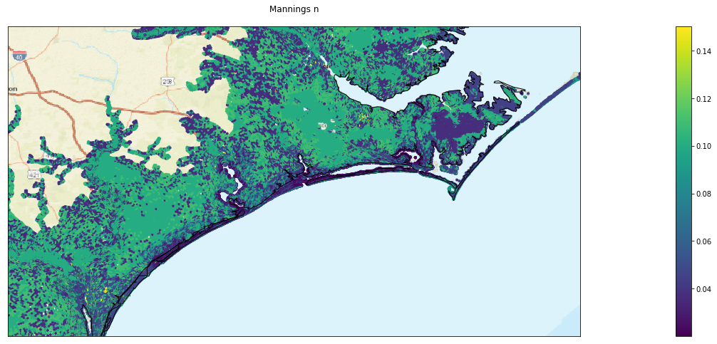

```python
nc = nc4.Dataset(os.path.join(root_dir,'input_fort.nc'),'r')
grp = nc.groups['mannings_n_at_sea_floor']
lat1,lat2 = 34.059, 35.25
lon1,lon2 = -78.25, -76.05
title = 'Mannings n'
fig,ax=plt.subplots(figsize=(48,8))
adcirc.attr_plot(grp,title,ax,lat1,lat2,lon1,lon2)
```

#### QC Comments: (date if applicable)

#### QC Response

#### Surface Canopy Coefficient in the Study Area

- Turns off the wind stress in heavily forested areas that have been flooded (marshes, swamps, etc). The canopy shields the water from the effect of the wind.
- Zero if the wind stress should be zero because of a canopy. One otherwise.

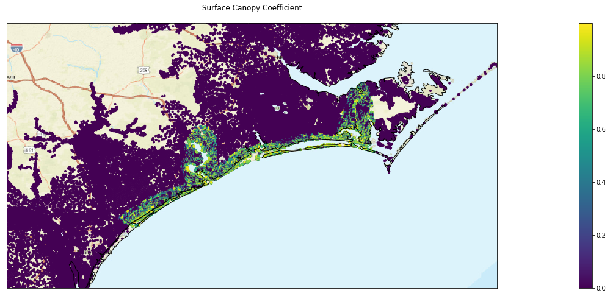

```python
nc = nc4.Dataset(os.path.join(root_dir,'input_fort.nc'),'r')
grp = nc.groups['surface_canopy_coefficient']
lat1,lat2 = 34.059, 35.25
lon1,lon2 = -78.25, -76.05
title = 'Surface Canopy Coefficient'
fig,ax=plt.subplots(figsize=(48,8))
adcirc.attr_plot(grp,title,ax,lat1,lat2,lon1,lon2)
```

#### QC Comments: (8-1-2018)

Canopy should be 0 or 1, is this a plotting issue? please verify.

#### QC Response

#### Average Horizontal Eddy Viscosity in Sea Water in the Study Area

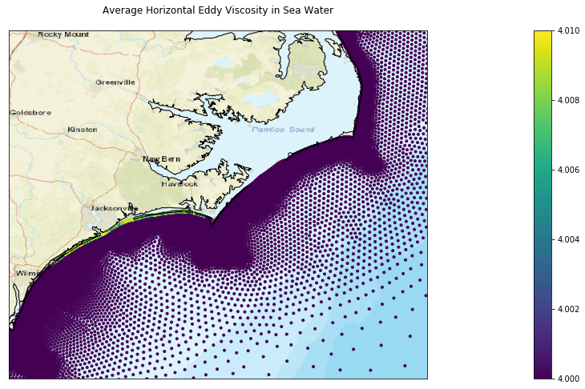

```python
nc = nc4.Dataset(os.path.join(root_dir,'input_fort.nc'),'r')
grp = nc.groups['average_horizontal_eddy_viscosity_in_sea_water_wrt_depth']
lat1,lat2 = 33.5, 36
lon1,lon2 = -78, -75
data = 'Data'
title = 'Average Horizontal Eddy Viscosity in Sea Water'
fig,ax=plt.subplots(figsize=(48,8))
adcirc.attr_plot(grp,title,ax,lat1,lat2,lon1,lon2)
```

#### QC Comments: (date if applicable)

#### QC Response

#### Primitive Weighting in Continuity Equation in the Study Area

- Weighting factor that weights the relative contribution of the primitive and wave portions of the GWCE.

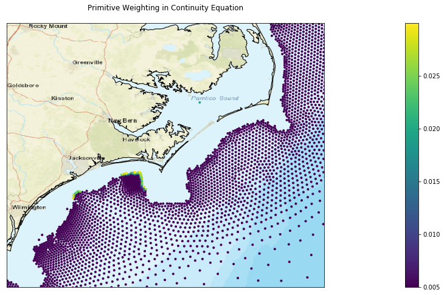

```python
nc = nc4.Dataset(os.path.join(root_dir,'input_fort.nc'),'r')
grp = nc.groups['primitive_weighting_in_continuity_equation']
lat1,lat2 = 33.5, 36
lon1,lon2 = -78, -75
title = 'Primitive Weighting in Continuity Equation'
fig,ax=plt.subplots(figsize=(48,8))
adcirc.attr_plot(grp,title,ax,lat1,lat2,lon1,lon2)
```

#### QC Comments: (date if applicable)

#### QC Response

#### Wave Refraction in Swan in the Study Area

- Turn wave refraction on or off in the SWAN calculations during a coupled ADCIRC+SWAN run.

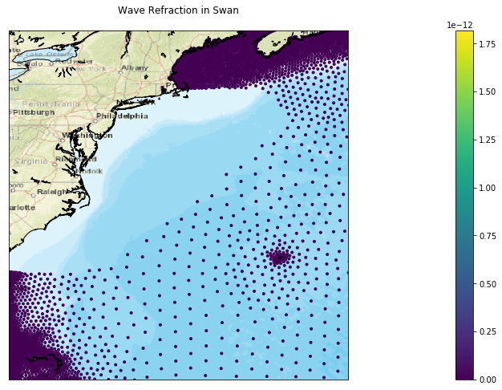

```python
nc = nc4.Dataset(os.path.join(root_dir,'input_fort.nc'),'r')
grp = nc.groups['wave_refraction_in_swan']
lat1,lat2 = 25.5, 45
lon1,lon2 = -80, -61
title = 'Wave Refraction in Swan'
fig,ax=plt.subplots(figsize=(48,8))
adcirc.attr_plot(grp,title,ax,lat1,lat2,lon1,lon2)
```

#### QC Comments: (date if applicable)

#### QC Response

#### Surface Directional Effective Roughness Length All Directions Plot

- A measure of the “roughness” of the land that can impede wind flow and reduce the surface stress that the wind applies. The ocean would be considered very smooth, and skyscrapers would be considered very rough. This attribute is directional, and the twelve values represent the roughness lengths “seen” by winds blowing from twelve different compass directions at each node.
- The orientation of the twelve values follows the trigonometric convention, that is, zero degrees represents due east, and the values proceed counter clockwise. In other words, the first value at a node is applied to winds blowing from west to east, the second value applies to winds blowing East-Northeast, etc.

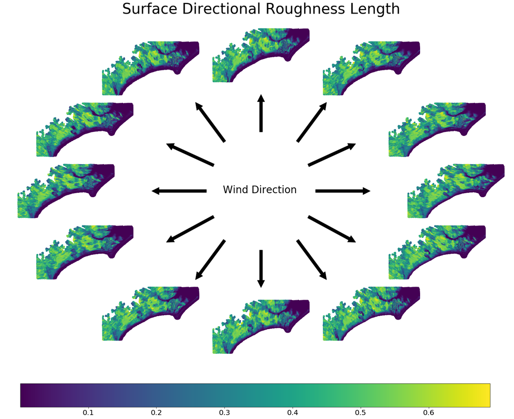

```python
# Plots all 12 directions of the surface directional roughness
# It takes about 20min to plot this
nc = nc4.Dataset(os.path.join(root_dir,'input_fort.nc'),'r')
grp = nc.groups['surface_directional_effective_roughness_length']
lat1,lat2 = 34.059, 35.25
lon1,lon2 = -78.25, -76.05
fig = plt.figure(figsize=(18,10))
adcirc.plot_surf_dir(grp,lat1,lat2,lon1,lon2)
```

#### QC Comments: (date if applicable)

#### QC Response

### Select Direction to zoom in

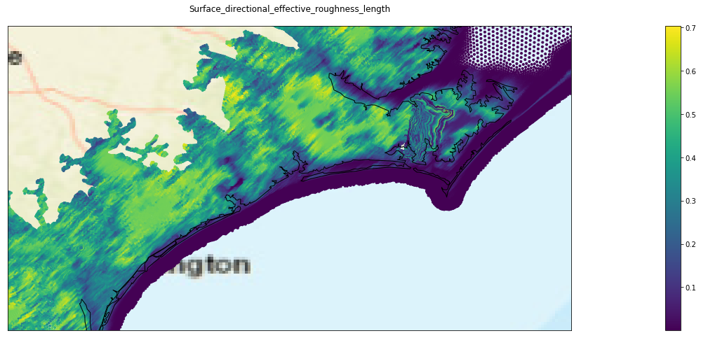

```python
# Plots only one direction of the surface directional roughness
nc = nc4.Dataset(os.path.join(root_dir,'input_fort.nc'),'r')
grp = nc.groups['surface_directional_effective_roughness_length']
lat1,lat2 = 34.059, 35.25
lon1,lon2 = -78.25, -76.05
data = 'NE' # changing this variable to the chosen direction (E,ENE,NE,N,NW,WNW,W,WSW,SW,S,SE,ESE)
pixels=200
title = 'Surface_directional_effective_roughness_length'
fig,ax=plt.subplots(figsize=(48,8))
adcirc.attr_plot(grp,title,ax,lat1,lat2,lon1,lon2,data,pixels)
```

```python
# Assign date of QC & Name/Info of QC Staff
qc_date = datetime.now()
print('QC Completed on {} by {}, awaiting responses'.format(qc_date, qc_staff))
```

[output not shown]

## End